# Logistic models to assess tolerance

Madyline Lawrence, Moria Chambers & Owais Gilani

6/17/2022

# Goal: To determine how chronic infection alters the ability to tolerate secondary infections of unrelated bacteria

## Ready the workspace

```r
rm(list=ls()) #removes all old variables

#import the dataset
efdata = read.csv("E.fae data.csv")
smdata = read.csv("S.m data.csv")

ef.bygroup = distinct(efdata, scientist,rep, primary, secondary_dose, X0.hour, X10.hour, log10_10hour)
sm.bygroup = distinct(smdata, scientist, rep, primary, secondary_dose, X0.hour, X10.hour, log10_10hour)
```

# Chronic infection with *S. marcescens*

## Full Logistic Model

- Does chronic infection with *S. marcescens* significantly impact tolerance to secondary infection with *P. rettgeri*?
- We assessed this by determining whether chronic infection significantly impacts the relationship between log 10 (bacterial load at 10 hours post-secondary infection) and survival three days post-secondary infection.

```r
mylogit = glm(formula = bin_alive3 ~ log10_10hour + bin_primary + (bin_primary*log10_10hour), family = "binomial", data = smdata)
summary(mylogit)
```

```
##
## Call:
## glm(formula = bin_alive3 ~ log10_10hour + bin_primary + (bin_primary *
##     log10_10hour), family = "binomial", data = smdata)
##
## Deviance Residuals:
##     Min       1Q   Median       3Q      Max
## -1.8933  -0.8277  -0.3511   0.8649   2.3959
##
## Coefficients:
##                          Estimate Std. Error z value Pr(>|z|)
## (Intercept)                3.9326     0.5881   6.687 2.28e-11 ***
## log10_10hour              -1.0634     0.1227  -8.664  < 2e-16 ***
## bin_primary               -1.6209     0.6989  -2.319   0.0204 *
## log10_10hour:bin_primary   0.6592     0.1497   4.402 1.07e-05 ***
## ---
## Signif. codes:  0 '***' 0.001 '**' 0.01 '*' 0.05 '.' 0.1 ' ' 1
##
## (Dispersion parameter for binomial family taken to be 1)
##
##     Null deviance: 1532.5  on 1120  degrees of freedom
## Residual deviance: 1192.0  on 1117  degrees of freedom
## AIC: 1200
##
## Number of Fisher Scoring iterations: 5
```

```r
# C-Statistic
cat(paste("C-Statistic =", round(Cstat(mylogit), 4)))
```

```
## C-Statistic = 0.7934
```

- **Conclusion** - Yes, chronic infection with *S. marcesens* has a significant impact on survival three days post-infection (p = 0.02) and significantly impacts the relationship between log(10 hour bacterial load) and survival at three days post-infection (p << 0.001).

## Values of Interest

```r
# Function to calculate Inflection Point
inflection.point <- function(beta0, beta1){
  return(as.numeric(-beta0/beta1))
}

# Function to calculate Hill's Slope
hill.slope <- function(beta0, beta1){
  x <- -beta0/beta1
  u <- beta0+beta1*x
  return(as.numeric(beta1*exp(u)/(1+exp(u))^2))
}
```

```r
# PBS curve point of inflection
inflection.point(beta0=mylogit$coefficients[1], beta1=mylogit$coefficients[2])

# PBS Hill's slope
hill.slope(beta0=mylogit$coefficients[1], beta1=mylogit$coefficients[2])

# S. Marcescens Curve point of inflection
inflection.point(beta0=(mylogit$coefficients[1]+mylogit$coefficients[3]),
                 beta1=(mylogit$coefficients[2]+mylogit$coefficients[4]))

# S. Marcescens Hill's slope
hill.slope(beta0=(mylogit$coefficients[1]+mylogit$coefficients[3]),
           beta1=(mylogit$coefficients[2]+mylogit$coefficients[4]))
```

- PBS curve point of inflection = 3.6981
- PBS hill slope = -0.26585
- *S. marcescens* curve point of inflection = 5.71890
- *S. marcescens* hill slope = -0.10105

## Figure 3C

```r
bact_val <- seq(2,9,0.01)
PBS_predict_data <- data.frame(log10_10hour = bact_val,
                               bin_primary = c(rep(0, length(bact_val))))
# PBS Prediction
PBS_preds <- predict(mylogit, newdata = PBS_predict_data, type = "response", se.fit = TRUE)
PBS_upper = (PBS_preds$fit+(1.96*PBS_preds$se.fit))
PBS_lower = (PBS_preds$fit-(1.96*PBS_preds$se.fit))

# SM Prediction
SM_predict_data <- data.frame(log10_10hour = bact_val,
                              bin_primary = c(rep(1, length(bact_val))))
SM_preds <- predict(mylogit, newdata=SM_predict_data, type = "response", se.fit = TRUE)
SM_upper = (SM_preds$fit+(1.96*SM_preds$se.fit))
SM_lower = (SM_preds$fit-(1.96*SM_preds$se.fit))
```

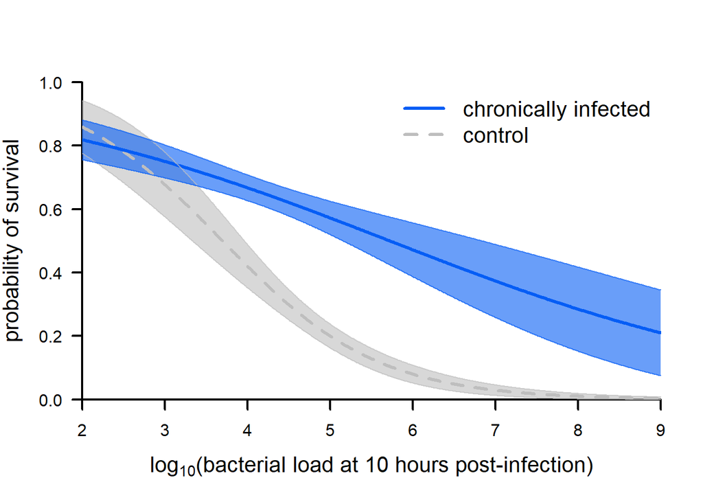

# Chronic infection with *E. faecalis*

## Full Logistic Model

- Does chronic infection with *E. faecalis* significantly impact tolerance to secondary infection with *P. rettgeri*?
- We assessed this by determining whether chronic infection significantly impacts the relationship between log 10 (bacterial load at 10 hours post-secondary infeciton) and survival three days post-secondary infection.

```r
mylogit_Ef = glm(formula = bin_alive3 ~ log10_10hour + bin_primary + (bin_primary*log10_10hour), family = "binomial", data = efdata)
summary(mylogit_Ef)
```

```
##
## Call:
## glm(formula = bin_alive3 ~ log10_10hour + bin_primary + (bin_primary *
##     log10_10hour), family = "binomial", data = efdata)
##
## Deviance Residuals:
##     Min       1Q   Median       3Q      Max
## -1.5360  -0.9492  -0.6317   1.1450   2.0811
##
## Coefficients:
##                          Estimate Std. Error z value Pr(>|z|)
## (Intercept)               2.27999    0.51559   4.422 9.78e-06 ***
## log10_10hour             -0.61920    0.09602  -6.448 1.13e-10 ***
## bin_primary               0.16703    0.68466   0.244    0.807
## log10_10hour:bin_primary  0.08319    0.12989   0.640    0.522
## ---
## Signif. codes:  0 '***' 0.001 '**' 0.01 '*' 0.05 '.' 0.1 ' ' 1
##
## (Dispersion parameter for binomial family taken to be 1)
##
##     Null deviance: 1465.1  on 1151  degrees of freedom
## Residual deviance: 1338.1  on 1148  degrees of freedom
## AIC: 1346.1
##
## Number of Fisher Scoring iterations: 4
```

```r
# C-Statistic
cat(paste("C-Statistic =", round(Cstat(mylogit_Ef), 4)))
```

```
## C-Statistic = 0.6997
```

- **Conclusion** - No, chronic infection with *E. faecalis* does not significantly impact the relationship between log(10 hour bacterial load) and survival at three days post-infection (p = 0.52). Therefore we removed this from the model to better assess the overall impact of chronic infection with *E. faecalis*

## Reduced Logistic Model

```r
## Since the interaction term isn't significant, removed it from the model and reran
mylogit_Ef_redux = glm(formula = bin_alive3 ~ log10_10hour + bin_primary, family = "binomial", data = efdata)
summary(mylogit_Ef_redux)
```

```
##
## Call:
## glm(formula = bin_alive3 ~ log10_10hour + bin_primary, family = "binomial",
##     data = efdata)
##
## Deviance Residuals:
##     Min       1Q   Median       3Q      Max
## -1.5703  -0.9407  -0.6425   1.1690   2.0486
##
## Coefficients:
##              Estimate Std. Error z value Pr(>|z|)
## (Intercept)   2.04211    0.35563   5.742 9.34e-09 ***
## log10_10hour -0.57422    0.06473  -8.871  < 2e-16 ***
## bin_primary   0.59739    0.13352   4.474 7.67e-06 ***
## ---
## Signif. codes:  0 '***' 0.001 '**' 0.01 '*' 0.05 '.' 0.1 ' ' 1
##
## (Dispersion parameter for binomial family taken to be 1)
##
##     Null deviance: 1465.1  on 1151  degrees of freedom
## Residual deviance: 1338.5  on 1149  degrees of freedom
## AIC: 1344.5
##
## Number of Fisher Scoring iterations: 3
```

```r
anova(mylogit_Ef_redux, mylogit_Ef)
```

```
## Analysis of Deviance Table
##
## Model 1: bin_alive3 ~ log10_10hour + bin_primary
## Model 2: bin_alive3 ~ log10_10hour + bin_primary + (bin_primary * log10_10hour)
##   Resid. Df Resid. Dev Df Deviance
## 1      1149     1338.5
## 2      1148     1338.1  1  0.41053
```

```r
cat(paste("C-Statistic =", round(Cstat(mylogit_Ef_redux), 4)))
```

```
## C-Statistic = 0.7001
```

- **Conclusion** - Chronic infection with *E. faecalis* significantly impacts survival at three days post-infection (p<0.001)

## Values of Interest

```r
# Function to calculate Inflection Point
inflection.point <- function(beta0, beta1){
  return(as.numeric(-beta0/beta1))
}

# Function to calculate Hill's Slope
hill.slope <- function(beta0, beta1){
  x <- -beta0/beta1
  u <- beta0+beta1*x
  return(as.numeric(beta1*exp(u)/(1+exp(u))^2))
}
```

```r
# PBS curve point of inflection
inflection.point(beta0=mylogit_Ef_redux$coefficients[1], beta1=mylogit_Ef_redux$coefficients[2])

# PBS Hill's slope
hill.slope(beta0=mylogit_Ef_redux$coefficients[1], beta1=mylogit_Ef_redux$coefficients[2])

# E.faecalis Curve point of inflection
inflection.point(beta0=(mylogit_Ef_redux$coefficients[1]+mylogit_Ef_redux$coefficients[3]),
                 beta1=(mylogit_Ef_redux$coefficients[2]))

# E.faecalis Hill's slope
hill.slope(beta0=(mylogit_Ef_redux$coefficients[1]+mylogit_Ef_redux$coefficients[3]),
           beta1=(mylogit_Ef_redux$coefficients[2]))
```

[output not shown]

## Figure 3D

```r
bact_val = seq(2,9,0.01)
PBS_predict_data <- data.frame(log10_10hour = bact_val,
                               bin_primary = c(rep(0, length(bact_val))))

PBS_preds <- predict(mylogit_Ef_redux, newdata=PBS_predict_data, type = "response",se.fit =TRUE)
PBS_upper = (PBS_preds$fit+1.96*PBS_preds$se.fit)
PBS_lower = (PBS_preds$fit-1.96*PBS_preds$se.fit)

Efae_predict_data <- data.frame(log10_10hour = bact_val,
                                bin_primary = c(rep(1, length(bact_val))))

Efae_preds <- predict(mylogit_Ef_redux, newdata=Efae_predict_data, type = "response",se.fit = TRUE)
Efae_upper = (Efae_preds$fit+(1.96*Efae_preds$se.fit))
Efae_lower = (Efae_preds$fit-(1.96*Efae_preds$se.fit))
```

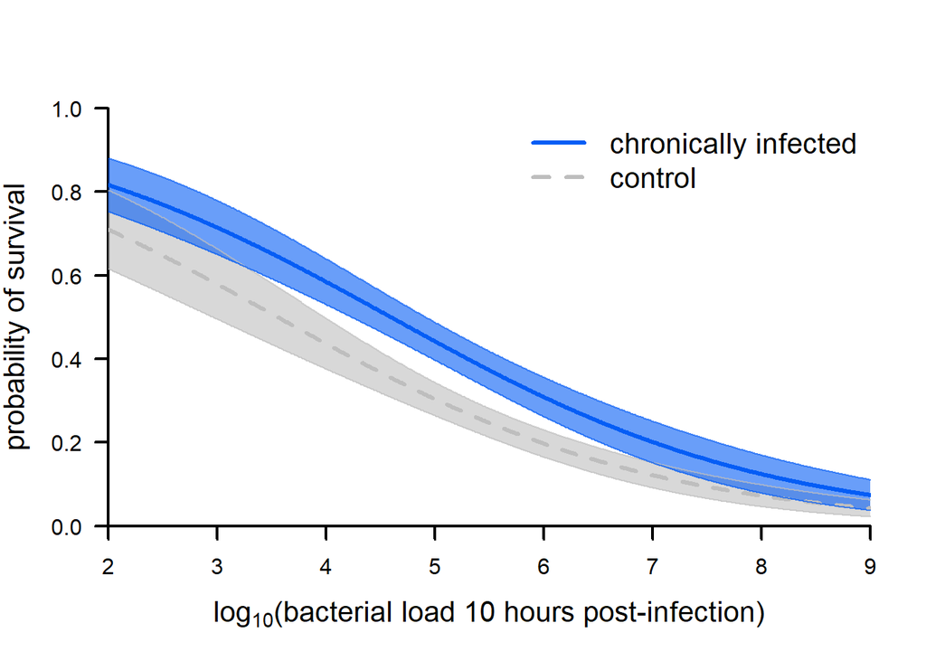